# R Notebook

# About the data

| Sample Name | Group | Gender | YOB | Mutation |
| --- | --- | --- | --- | --- |
| 2338 | control | M | 1982 | RYR1 c.7300G>A |
| 1325 | control | M | 1974 | RYR1 c.14545G>A |
| 2539 | control | F | 1968 | RYR1 c.1840C>T |
| 1806 | control | M | 1972 | RYR1 c.6617C>T |
| 963 | patient | F | 1982 | RYR1 c.14422-14423TT>AA |
| 1762 | patient | M | 1987 | RYR1 c.718N>T&c.2897N>T |
| 1834 | patient | M | 1977 | RYR1 c.13891TG>C |
| 433 | patient | F | 1973 | RYR1 c.14818G>C |

# Quality control

## FastQC

https://www.bioinformatics.babraham.ac.uk/projects/fastqc/

All reports can be found in FastQC_reports folder.

Interpret the report: http://www.bioinformatics.babraham.ac.uk/projects/fastqc/Help/3%20Analysis%20Modules/

It comes to attention that the data failed on sequence duplication levels module. This is because FastQC assumes that the library is diverse, which is not valid for RNA-Seq libraries. It’s common to observe high duplication levels. According to the developer of FastQC, the duplication levels plots actually indicate a good RNA-Seq library. See: http://proteo.me.uk/2013/09/a-new-way-to-look-at-duplication-in-fastqc-v0-11/

Another issue raised in Kmer(nucleotide sequences of fixed k length) content module, some overrepresented sequences caused the Kmers to be highly enriched.

## SortMeRNA

This step is optional.

A tool for rRNA removel: https://github.com/biocore/sortmerna/blob/master/SortMeRNA-User-Manual-2.1.pdf

Index the rRNA databases(~3mins):

```bash
indexdb_rna --ref ./rRNA_databases/silva-bac-16s-id90.fasta,./index/silva-bac-16s:\
./rRNA_databases/silva-bac-23s-id98.fasta,./index/silva-bac-23s:\
./rRNA_databases/silva-arc-16s-id95.fasta,./index/silva-arc-16s:\
./rRNA_databases/silva-arc-23s-id98.fasta,./index/silva-arc-23s:\
./rRNA_databases/silva-euk-18s-id95.fasta,./index/silva-euk-18s:\
./rRNA_databases/silva-euk-28s-id98.fasta,./index/silva-euk-28s:\
./rRNA_databases/rfam-5.8s-database-id98.fasta,./index/rfam-5.8s:\
./rRNA_databases/rfam-5s-database-id98.fasta,./index/rfam-5s
```

Merge reads(~5mins):

```bash
./scripts/merge-paired-reads.sh ../S050/processed/433_S1_L008_R1_001.fastq ../S050/processed/433_S1_L008_R2_001.fastq ../sortmerna/433.fastq
```

Filter rRNA from reads:

```bash
sortmerna --ref \
./rRNA_databases/silva-bac-16s-id90.fasta,./index/silva-bac-16s:\
./rRNA_databases/silva-bac-23s-id98.fasta,./index/silva-bac-23s:\
./rRNA_databases/silva-arc-16s-id95.fasta,./index/silva-arc-16s:\
./rRNA_databases/silva-arc-23s-id98.fasta,./index/silva-arc-23s:\
./rRNA_databases/silva-euk-18s-id95.fasta,./index/silva-euk-18s:\
./rRNA_databases/silva-euk-28s-id98.fasta,./index/silva-euk-28s:\
./rRNA_databases/rfam-5s-database-id98.fasta,./index/rfam-5s:\
./rRNA_databases/rfam-5.8s-database-id98.fasta,./index/rfam-5.8s \
--reads ../sortmerna/433.fastq \
--fastx --aligned ../sortmerna/433_reads_rRNA --other ../sortmerna/433_reads_non_rRNA --log -a 8 --paired_in -v
```

Unmerged filtered reads:

```bash
./scripts/unmerge-paired-reads.sh ../sortmerna/433_reads_non_rRNA.fastq ../sortmerna/433_reads_non_rRNA_1.fastq  ../sortmerna/433_reads_non_rRNA_2.fastq
```

## sickle

This step is optional.

A trimming tool: https://github.com/ucdavis-bioinformatics/sickle

```bash
sickle pe -f ../S050/processed/433_S1_L008_R1_001.fastq -r ../S050/processed/433_S1_L008_R2_001.fastq -t sanger -o 433_trimmed_file1.fastq  -p 433_trimmed_file2.fastq -s 433_trimmed_singles.fastq
```

screen output:

```bash
PE forward file: ../S050/processed/433_S1_L008_R1_001.fastq
PE reverse file: ../S050/processed/433_S1_L008_R2_001.fastq

Total input FastQ records: 44787394 (22393697 pairs)

FastQ paired records kept: 44311318 (22155659 pairs)
FastQ single records kept: 235835 (from PE1: 228188, from PE2: 7647)
FastQ paired records discarded: 4406 (2203 pairs)
FastQ single records discarded: 235835 (from PE1: 7647, from PE2: 228188)
```

Comparing to the original data, the trimmed data doesn’t show a better quality. So we abandoned this method.

# Alignment

## Pipeline 1

### HISAT2

https://ccb.jhu.edu/software/hisat2/manual.shtml

#### 1.Indexing the reference genome

```bash
hisat2-build ../hg38/fasta/Homo_sapiens.GRCh38.dna.primary_assembly.fa ./PRI
```

The command outputs 8 files: *PRI.1.ht2 PRI.2.ht2 PRI.3.ht2 PRI.4.ht2 PRI.5.ht2 PRI.6.ht2 PRI.7.ht2 PRI.8.ht2*

#### 2.Aligning reads

First try with 433 file using a single quota(~45mins)

```bash
hisat2 -x ./PRI -1 ../S050/processed/433_S1_L008_R1_001.fastq -2 ../S050/processed/433_S1_L008_R2_001.fastq -S 433.sam --rna-strandness RF
```

Screen output:

```bash
22393697 reads; of these:
  22393697 (100.00%) were paired; of these:
    1694708 (7.57%) aligned concordantly 0 times
    19436420 (86.79%) aligned concordantly exactly 1 time
    1262569 (5.64%) aligned concordantly >1 times
    ----
    1694708 pairs aligned concordantly 0 times; of these:
      695692 (41.05%) aligned discordantly 1 time
    ----
    999016 pairs aligned 0 times concordantly or discordantly; of these:
      1998032 mates make up the pairs; of these:
        1304348 (65.28%) aligned 0 times
        604143 (30.24%) aligned exactly 1 time
        89541 (4.48%) aligned >1 times
97.09% overall alignment rate
```

File output: *433.sam*

Second try with 963 file using 20 quotas(~6mins)

```bash
hisat2 -p 20 -x ./PRI -1 ../S050/processed/963_S2_L008_R1_001.fastq -2 ../S050/processed/963_S2_L008_R2_001.fastq -S 963.sam --rna-strandness RF
```

Screen output:

```bash
23082561 reads; of these:
  23082561 (100.00%) were paired; of these:
    1856948 (8.04%) aligned concordantly 0 times
    20115736 (87.15%) aligned concordantly exactly 1 time
    1109877 (4.81%) aligned concordantly >1 times
    ----
    1856948 pairs aligned concordantly 0 times; of these:
      801355 (43.15%) aligned discordantly 1 time
    ----
    1055593 pairs aligned 0 times concordantly or discordantly; of these:
      2111186 mates make up the pairs; of these:
        1368042 (64.80%) aligned 0 times
        650589 (30.82%) aligned exactly 1 time
        92555 (4.38%) aligned >1 times
97.04% overall alignment rate
```

File output: *963.sam*

1325 file

```bash
21238177 reads; of these:
  21238177 (100.00%) were paired; of these:
    2439728 (11.49%) aligned concordantly 0 times
    17777487 (83.71%) aligned concordantly exactly 1 time
    1020962 (4.81%) aligned concordantly >1 times
    ----
    2439728 pairs aligned concordantly 0 times; of these:
      1090722 (44.71%) aligned discordantly 1 time
    ----
    1349006 pairs aligned 0 times concordantly or discordantly; of these:
      2698012 mates make up the pairs; of these:
        1911042 (70.83%) aligned 0 times
        685274 (25.40%) aligned exactly 1 time
        101696 (3.77%) aligned >1 times
95.50% overall alignment rate
```

File output: *1325.sam*

1762 file

```bash
26675014 reads; of these:
  26675014 (100.00%) were paired; of these:
    3579861 (13.42%) aligned concordantly 0 times
    21557902 (80.82%) aligned concordantly exactly 1 time
    1537251 (5.76%) aligned concordantly >1 times
    ----
    3579861 pairs aligned concordantly 0 times; of these:
      1578888 (44.10%) aligned discordantly 1 time
    ----
    2000973 pairs aligned 0 times concordantly or discordantly; of these:
      4001946 mates make up the pairs; of these:
        2876526 (71.88%) aligned 0 times
        968958 (24.21%) aligned exactly 1 time
        156462 (3.91%) aligned >1 times
94.61% overall alignment rate
```

File output: *1762.sam*

1806 file

```bash
26855911 reads; of these:
  26855911 (100.00%) were paired; of these:
    2681823 (9.99%) aligned concordantly 0 times
    22924217 (85.36%) aligned concordantly exactly 1 time
    1249871 (4.65%) aligned concordantly >1 times
    ----
    2681823 pairs aligned concordantly 0 times; of these:
      1215712 (45.33%) aligned discordantly 1 time
    ----
    1466111 pairs aligned 0 times concordantly or discordantly; of these:
      2932222 mates make up the pairs; of these:
        2015843 (68.75%) aligned 0 times
        802650 (27.37%) aligned exactly 1 time
        113729 (3.88%) aligned >1 times
96.25% overall alignment rate
```

File output: *1806.sam*

1834 file

```bash
23999083 reads; of these:
  23999083 (100.00%) were paired; of these:
    2359967 (9.83%) aligned concordantly 0 times
    20595048 (85.82%) aligned concordantly exactly 1 time
    1044068 (4.35%) aligned concordantly >1 times
    ----
    2359967 pairs aligned concordantly 0 times; of these:
      1067482 (45.23%) aligned discordantly 1 time
    ----
    1292485 pairs aligned 0 times concordantly or discordantly; of these:
      2584970 mates make up the pairs; of these:
        1754419 (67.87%) aligned 0 times
        734819 (28.43%) aligned exactly 1 time
        95732 (3.70%) aligned >1 times
96.34% overall alignment rate
```

File output: *1834.sam*

2338 file

```bash
26361273 reads; of these:
  26361273 (100.00%) were paired; of these:
    3081323 (11.69%) aligned concordantly 0 times
    22122914 (83.92%) aligned concordantly exactly 1 time
    1157036 (4.39%) aligned concordantly >1 times
    ----
    3081323 pairs aligned concordantly 0 times; of these:
      1383307 (44.89%) aligned discordantly 1 time
    ----
    1698016 pairs aligned 0 times concordantly or discordantly; of these:
      3396032 mates make up the pairs; of these:
        2410452 (70.98%) aligned 0 times
        857368 (25.25%) aligned exactly 1 time
        128212 (3.78%) aligned >1 times
95.43% overall alignment rate
```

File output: *2338.sam*

2539 file

```bash
25701263 reads; of these:
  25701263 (100.00%) were paired; of these:
    2394938 (9.32%) aligned concordantly 0 times
    21957124 (85.43%) aligned concordantly exactly 1 time
    1349201 (5.25%) aligned concordantly >1 times
    ----
    2394938 pairs aligned concordantly 0 times; of these:
      1065463 (44.49%) aligned discordantly 1 time
    ----
    1329475 pairs aligned 0 times concordantly or discordantly; of these:
      2658950 mates make up the pairs; of these:
        1790623 (67.34%) aligned 0 times
        753814 (28.35%) aligned exactly 1 time
        114513 (4.31%) aligned >1 times
96.52% overall alignment rate
```

File output: *2539.sam*

### Samtools

http://www.htslib.org/doc/samtools.html

#### Prerequisites:

zlib-devel installed http://zlib.net/

htslib and bcftools installed

https://github.com/samtools/htslib

https://github.com/samtools/bcftools

#### 1.Convert the SAM file into a BAM file (~10mins)

*e.g. 433.sam to 433.bam*

```bash
samtools view -bS 433.sam > 433.bam
```

To convert the rest of 8 files, launch a batch job on Rosalind and fill a cup of coffee.

*a sample of bash script:*

```bash
#!/bin/sh
#$ -pe smp 6
#$ -cwd
#$ -N convert_BAM
#$ -j y
#$ -l mem_free=28G
#$ -l h_rt=02:00:00
module load bioinformatics/samtools/1.5
samtools view -bS ../hisat2/963.sam > 963.bam
samtools view -bS ../hisat2/1325.sam > 1325.bam
samtools view -bS ../hisat2/1762.sam > 1762.bam
samtools view -bS ../hisat2/1806.sam > 1806.bam
samtools view -bS ../hisat2/1834.sam > 1834.bam
samtools view -bS ../hisat2/2338.sam > 2338.bam
samtools view -bS ../hisat2/2539.sam > 2539.bam
```

#### 2.Sort BAM file (~10mins)

*e.g. sort 433.bam by position*

```bash
samtools sort 433.bam -o 433.sorted.bam
```

Again, batch job

```bash
#!/bin/sh
#$ -pe smp 6
#$ -cwd
#$ -N sort_BAM
#$ -j y
#$ -l mem_free=28G
#$ -l h_rt=02:00:00
module load bioinformatics/samtools/1.5
samtools sort 963.bam -o 963.sorted.bam
samtools sort 1325.bam -o 1325.sorted.bam
samtools sort 1762.bam -o 1762.sorted.bam
samtools sort 1806.bam -o 1806.sorted.bam
samtools sort 1834.bam -o 1834.sorted.bam
samtools sort 2338.bam -o 2338.sorted.bam
samtools sort 2539.bam -o 2539.sorted.bam
```

```bash
python infer_experiment.py -i ../../sharedscratch/samtools/1834.sorted.bam -r ../../sharedscratch/hg38/gtf/Homo_sapiens.GRCh38.89.bed
```

```bash
This is PairEnd Data
Fraction of reads failed to determine: 0.0559
Fraction of reads explained by "1++,1--,2+-,2-+": 0.0121
Fraction of reads explained by "1+-,1-+,2++,2--": 0.9320
```

### HTSeq

http://htseq.readthedocs.io/en/release_0.9.1/

#### Generate reads count table (~55mins)

```bash
htseq-count -f bam -r pos -s reverse -i gene_id -t exon ../samtools/433.sorted.bam Homo_sapiens.GRCh38.gtf > 433.count.txt
```

batch job for the rest files

```bash
#!/bin/sh
#$ -pe smp 6
#$ -cwd
#$ -N read_count
#$ -j y
#$ -l mem_free=28G
#$ -l h_rt=20:00:00
module load general/python/2.7.10
htseq-count -f bam -r pos -s reverse -i gene_id -t exon ../samtools/433.sorted.bam ../hg38/gtf/Homo_sapiens.GRCh38.89.gtf > 433.count.txt
htseq-count -f bam -r pos -s reverse -i gene_id -t exon ../samtools/963.sorted.bam ../hg38/gtf/Homo_sapiens.GRCh38.89.gtf > 963.count.txt
htseq-count -f bam -r pos -s reverse -i gene_id -t exon ../samtools/1325.sorted.bam     ../hg38/gtf/Homo_sapiens.GRCh38.89.gtf > 1325.count.txt
htseq-count -f bam -r pos -s reverse -i gene_id -t exon ../samtools/1762.sorted.bam     ../hg38/gtf/Homo_sapiens.GRCh38.89.gtf > 1762.count.txt
htseq-count -f bam -r pos -s reverse -i gene_id -t exon ../samtools/1806.sorted.bam     ../hg38/gtf/Homo_sapiens.GRCh38.89.gtf > 1806.count.txt
htseq-count -f bam -r pos -s reverse -i gene_id -t exon ../samtools/1834.sorted.bam     ../hg38/gtf/Homo_sapiens.GRCh38.89.gtf > 1834.count.txt
htseq-count -f bam -r pos -s reverse -i gene_id -t exon ../samtools/2338.sorted.bam     ../hg38/gtf/Homo_sapiens.GRCh38.89.gtf > 2338.count.txt
htseq-count -f bam -r pos -s reverse -i gene_id -t exon ../samtools/2539.sorted.bam     ../hg38/gtf/Homo_sapiens.GRCh38.89.gtf > 2539.count.txt
```

part of 433.count.txt (size:1.1M)

```bash
ENSG00000000003 35
ENSG00000000005 8
ENSG00000000419 100
ENSG00000000457 107
ENSG00000000460 38
ENSG00000000938 25
ENSG00000000971 640
ENSG00000001036 114
...
```

## Pipeline 2

### STAR

http://labshare.cshl.edu/shares/gingeraslab/www-data/dobin/STAR/STAR.posix/doc/STARmanual.pdf

#### 1.Indexing the reference genome

This task is memory demanding. We need 30-40GB to generate an index for the human genome. Therefore, we reserve more memory for running the bash script.

```bash
#!/bin/sh
#$ -pe smp 20
#$ -cwd
#$ -N STAR_indexing
#$ -j y
#$ -l mem_free=50G
#$ -l h_vmem=19G
#$ -l h_rt=12:00:00
module load bioinformatics/STAR/2.5.2a
STAR --runThreadN 5 --runMode genomeGenerate --genomeDir ./genome  --genomeFastaFiles ../hg38/fasta/Homo_sapiens.GRCh38.dna.primary_assembly.fa --sjdbGTFfile ../hg38/gtf/Homo_sapiens.GRCh38.89.gtf --sjdbOverhang 124
```

#### 2.Mapping reads to the genome

```bash
#!/bin/sh
#$ -pe smp 20
#$ -cwd
#$ -N STAR_mapping
#$ -j y
#$ -l mem_free=50G
#$ -l h_vmem=19G
#$ -l h_rt=12:00:00
module load bioinformatics/STAR/2.5.2a
STAR --runThreadN 5 --genomeDir ./genome --readFilesIn ../S050/processed/433_S1_L008_R1_001.fastq ../S050/processed/433_S1_L008_R2_001.fastq --outSAMtype BAM SortedByCoordinate --quantMode GeneCounts --outFileNamePrefix ./433/433
STAR --runThreadN 5 --genomeDir ./genome --readFilesIn ../S050/processed/963_S2_L008_R1_001.fastq ../S050/processed/963_S2_L008_R2_001.fastq --outSAMtype BAM SortedByCoordinate --quantMode GeneCounts --outFileNamePrefix ./963/963
STAR --runThreadN 5 --genomeDir ./genome --readFilesIn ../S050/processed/1325_S3_L008_R1_001.fastq ../S050/processed/1325_S3_L008_R2_001.fastq --outSAMtype BAM SortedByCoordinate --quantMode GeneCounts --outFileNamePrefix ./1325/1325
STAR --runThreadN 5 --genomeDir ./genome --readFilesIn ../S050/processed/1762_S8_L008_R1_001.fastq ../S050/processed/1762_S8_L008_R2_001.fastq --outSAMtype BAM SortedByCoordinate --quantMode GeneCounts --outFileNamePrefix ./1762/1762
STAR --runThreadN 5 --genomeDir ./genome --readFilesIn ../S050/processed/1806_S4_L008_R1_001.fastq ../S050/processed/1806_S4_L008_R2_001.fastq --outSAMtype BAM SortedByCoordinate --quantMode GeneCounts --outFileNamePrefix ./1806/1806
STAR --runThreadN 5 --genomeDir ./genome --readFilesIn ../S050/processed/1834_S5_L008_R1_001.fastq ../S050/processed/1834_S5_L008_R2_001.fastq --outSAMtype BAM SortedByCoordinate --quantMode GeneCounts --outFileNamePrefix ./1834/1834
STAR --runThreadN 5 --genomeDir ./genome --readFilesIn ../S050/processed/2338_S6_L008_R1_001.fastq ../S050/processed/2338_S6_L008_R2_001.fastq --outSAMtype BAM SortedByCoordinate --quantMode GeneCounts --outFileNamePrefix ./2338/2338
STAR --runThreadN 5 --genomeDir ./genome --readFilesIn ../S050/processed/2539_S7_L008_R1_001.fastq ../S050/processed/2539_S7_L008_R2_001.fastq --outSAMtype BAM SortedByCoordinate --quantMode GeneCounts --outFileNamePrefix ./2539/2539
```

File output: *Aligned.sortedByCoord.out.bam ReadsPerGene.out.tab SJ.out.tab*

*ReadsPerGene.out.tab*

```bash
N_unmapped      1176314 1176314 1176314
N_multimapping  1260483 1260483 1260483
N_noFeature     6136326 18311385        6296366
N_ambiguous     1929598 19634   449025
ENSG00000223972 0       1       0
ENSG00000227232 14      1       14
ENSG00000278267 2       0       2
ENSG00000243485 1       0       1
ENSG00000284332 0       0       0
ENSG00000237613 0       0       0
ENSG00000268020 0       0       0
ENSG00000240361 0       0       0
...
```

*433Log.final.out*

```bash
                          Number of input reads |       22393697
                      Average input read length |       250
                                    UNIQUE READS:
                   Uniquely mapped reads number |       19956900
                        Uniquely mapped reads % |       89.12%
                          Average mapped length |       248.03
                       Number of splices: Total |       11326836
            Number of splices: Annotated (sjdb) |       11220196
                       Number of splices: GT/AG |       11234198
                       Number of splices: GC/AG |       70557
                       Number of splices: AT/AC |       3906
               Number of splices: Non-canonical |       18175
                      Mismatch rate per base, % |       0.17%
                         Deletion rate per base |       0.01%
                        Deletion average length |       1.62
                        Insertion rate per base |       0.01%
                       Insertion average length |       1.42
                             MULTI-MAPPING READS:
        Number of reads mapped to multiple loci |       1260483
             % of reads mapped to multiple loci |       5.63%
        Number of reads mapped to too many loci |       22306
             % of reads mapped to too many loci |       0.10%
                                  UNMAPPED READS:
       % of reads unmapped: too many mismatches |       0.00%
                 % of reads unmapped: too short |       5.10%
                     % of reads unmapped: other |       0.05%
                                  CHIMERIC READS:
                       Number of chimeric reads |       0
                            % of chimeric reads |       0.00%
```

*963Log.final.out*

```bash
                          Number of input reads |       23082561
                      Average input read length |       250
                                    UNIQUE READS:
                   Uniquely mapped reads number |       20712230
                        Uniquely mapped reads % |       89.73%
                          Average mapped length |       247.83
                       Number of splices: Total |       11970497
            Number of splices: Annotated (sjdb) |       11866105
                       Number of splices: GT/AG |       11874506
                       Number of splices: GC/AG |       75094
                       Number of splices: AT/AC |       3571
               Number of splices: Non-canonical |       17326
                      Mismatch rate per base, % |       0.16%
                         Deletion rate per base |       0.01%
                        Deletion average length |       1.59
                        Insertion rate per base |       0.01%
                       Insertion average length |       1.41
                             MULTI-MAPPING READS:
        Number of reads mapped to multiple loci |       1068116
             % of reads mapped to multiple loci |       4.63%
        Number of reads mapped to too many loci |       23954
             % of reads mapped to too many loci |       0.10%
                                  UNMAPPED READS:
       % of reads unmapped: too many mismatches |       0.00%
                 % of reads unmapped: too short |       5.49%
                     % of reads unmapped: other |       0.05%
                                  CHIMERIC READS:
                       Number of chimeric reads |       0
                            % of chimeric reads |       0.00%
```

# Differential Expression

### DESeq2

http://www.bioconductor.org/help/workflows/rnaseqGene/#differential-expression-analysis

```r
library(DESeq2)
sample_table <- read.table("./read_counts/sample.txt",header = TRUE)
dds <- DESeqDataSetFromHTSeqCount(sampleTable = sample_table ,directory = "./read_counts/HTSeq",design = ~ group)
dds
```

```
class: DESeqDataSet
dim: 58233 8
metadata(1): version
assays(1): counts
rownames(58233): ENSG00000000003 ENSG00000000005 ... ENSG00000284596 ENSG00000284600
rowData names(0):
colnames(8): 2338 1325 ... 1834 433
colData names(4): group gender YOB Mutation
```

Using STAR counts

```r
tem1 <- read.table("STAR/433ReadsPerGene.out.tab",skip = 4,header = FALSE)
tem2 <- read.table("STAR/963ReadsPerGene.out.tab",skip = 4,header = FALSE)
tem3 <- read.table("STAR/1325ReadsPerGene.out.tab",skip = 4,header = FALSE)
tem4 <- read.table("STAR/1762ReadsPerGene.out.tab",skip = 4,header = FALSE)
tem5 <- read.table("STAR/1806ReadsPerGene.out.tab",skip = 4,header = FALSE)
tem6 <- read.table("STAR/1834ReadsPerGene.out.tab",skip = 4,header = FALSE)
tem7 <- read.table("STAR/2338ReadsPerGene.out.tab",skip = 4,header = FALSE)
tem8 <- read.table("STAR/2539ReadsPerGene.out.tab",skip = 4,header = FALSE)
keeps <- c("V1","V4")
temp <- merge(tem1[keeps],tem2[keeps],by = "V1")
temp <- merge(temp,tem3[keeps],by = "V1")
temp <- merge(temp,tem4[keeps],by = "V1")
```

```
column names 'V4.x', 'V4.y' are duplicated in the result
```

```r
temp <- merge(temp,tem5[keeps],by = "V1")
```

```
column names 'V4.x', 'V4.y' are duplicated in the result
```

```r
temp <- merge(temp,tem6[keeps],by = "V1")
```

```
column names 'V4.x', 'V4.y', 'V4.x', 'V4.y' are duplicated in the result
```

```r
temp <- merge(temp,tem7[keeps],by = "V1")
```

```
column names 'V4.x', 'V4.y', 'V4.x', 'V4.y' are duplicated in the result
```

```r
temp <- merge(temp,tem8[keeps],by = "V1")
```

```
column names 'V4.x', 'V4.y', 'V4.x', 'V4.y', 'V4.x', 'V4.y' are duplicated in the result
```

```r
countData <- temp[,-1]
rownames(countData) <- temp$V1
colnames(countData) <- c("433","963","1325","1762","1806","1834","2338","2539")
group <- factor(c("patient","patient","control","patient","control","patient","control","control"))
dds_star <- DESeqDataSetFromMatrix(countData,DataFrame(group), ~ group)
dds_star
```

```
class: DESeqDataSet
dim: 58233 8
metadata(1): version
assays(1): counts
rownames(58233): ENSG00000000003 ENSG00000000005 ... ENSG00000284596 ENSG00000284600
rowData names(0):
colnames(8): 433 963 ... 2338 2539
colData names(1): group
```

Remove the rows that have no or nearly no information about the amount of gene expression.

```r
dds <- dds[ rowSums(counts(dds)) > 1, ]
nrow(dds)
```

```
[1] 29504
```

Correlation dendrogram of samples

```r
library(ape, warn.conflicts=FALSE)
d <- cor(assay(rlog(dds)), method="spearman")
hc <- hclust(dist(1-d))
png("./clustering.png")
plot.phylo(as.phylo(hc), type="p", edge.col="blue", edge.width=2, show.node.label=TRUE, no.margin=TRUE)
dev.off()
```

STAR data

```r
dds_star <- dds_star[ rowSums(counts(dds_star)) > 1, ]
nrow(dds_star)
```

```
[1] 30014
```

Normalization: transforms the count data to the log2 scale by pipeline1

```r
rld <- rlog(dds, blind = FALSE)
head(assay(rld), 10)
```

```
                    2338     1325     2539     1806      963     1762     1834      433
ENSG00000000003 5.502050 5.311522 5.595009 5.556844 5.554587 5.497003 5.346128 5.277912
ENSG00000000005 2.260573 2.247839 2.168710 2.219926 2.946287 2.169111 3.067921 2.553725
ENSG00000000419 6.993400 7.121059 7.005849 7.117903 7.048302 7.064276 6.989127 6.753278
ENSG00000000457 7.226028 7.017247 7.379250 7.133164 6.845043 6.924465 7.090937 6.829038
ENSG00000000460 5.226458 5.460901 5.524261 5.136919 5.296321 5.082857 5.118456 5.235134
ENSG00000000938 4.097028 3.981005 4.149752 4.181535 3.691658 4.200855 3.963815 4.261806
ENSG00000000971 8.287382 8.187443 7.730597 7.668512 8.981981 7.875074 8.919155 9.035040
ENSG00000001036 5.734452 5.789103 5.653283 5.896245 6.253377 5.464807 5.985949 6.439595
ENSG00000001084 7.166407 7.324975 7.515784 7.514699 7.612032 7.742699 7.738038 7.777649
ENSG00000001167 7.159723 6.634550 7.044668 7.055751 7.271757 7.149480 7.638647 7.369012
```

Sample distances

```r
sampleDists <- dist(t(assay(rld)))
sampleDists
```

```
         2338     1325     2539     1806      963     1762     1834
1325 41.01643
2539 41.53191 41.73081
1806 37.64158 39.01497 36.86217
963  59.27501 63.73789 58.51165 58.91137
1762 48.31023 48.62087 46.93126 43.64919 55.14854
1834 59.96893 66.86394 63.64471 60.63083 41.57131 56.79165
433  64.50330 71.90556 67.79826 68.47536 51.49002 62.89382 52.98440
```

STAR

```r
rld_star <- rlog(dds_star, blind = FALSE)
head(assay(rld_star), 10)
```

```
                     433      963     1325     1762     1806     1834     2338     2539
ENSG00000000003 5.172711 5.439096 5.162582 5.399126 5.499453 5.244480 5.268049 5.508002
ENSG00000000005 2.491839 2.823843 2.183596 2.104373 2.155386 2.985905 2.197732 2.102982
ENSG00000000419 6.746046 7.017211 7.087540 7.059797 7.086091 6.973655 6.958460 6.989212
ENSG00000000457 6.820925 6.771515 6.952798 6.885595 7.086118 7.052045 7.151043 7.342008
ENSG00000000460 5.156408 5.292621 5.377520 5.131041 5.118755 5.029377 5.261115 5.452462
ENSG00000000938 4.212721 3.586890 3.932451 4.110744 4.135453 3.841740 4.027752 4.101997
ENSG00000000971 8.953793 8.883434 8.126805 7.780357 7.642837 8.850310 8.200332 7.634193
ENSG00000001036 6.407351 6.216091 5.716630 5.425833 5.861736 5.908304 5.687749 5.594550
ENSG00000001084 7.724666 7.618354 7.293544 7.667223 7.466803 7.682026 7.150843 7.480608
ENSG00000001167 7.339781 7.212866 6.566926 7.068283 6.996254 7.599690 7.135853 6.988729
```

```r
sampleDists_star <- dist(t(assay(rld_star)))
sampleDists_star
```

```
          433      963     1325     1762     1806     1834     2338
963  51.43509
1325 72.37960 64.02445
1762 63.56866 55.55978 48.76274
1806 68.79872 58.95163 39.04872 43.88223
1834 52.90000 41.07152 67.17948 57.30730 60.69257
2338 64.86303 59.52543 41.33545 48.49408 37.78952 60.25702
2539 68.25876 58.68712 42.02003 47.19600 36.92305 63.79309 41.56678
```

Heatmap by sample distance

```r
library("pheatmap")
library("RColorBrewer")
sampleDistMatrix <- as.matrix( sampleDists )
rownames(sampleDistMatrix) <- paste( rld$group, colnames(assay(rld)), sep = " - " )
colnames(sampleDistMatrix) <-  NULL
colors <- colorRampPalette( rev(brewer.pal(9, "Reds")) )(255)
pheatmap(sampleDistMatrix,
         clustering_distance_rows = sampleDists,
         clustering_distance_cols = sampleDists,
         col = colors,filename = "./heat1.png")
```

by sample poisson distances

```r
library("PoiClaClu")
poisd <- PoissonDistance(t(counts(dds)))
samplePoisDistMatrix <- as.matrix( poisd$dd )
rownames(samplePoisDistMatrix) <- paste( rld$group, colnames(assay(rld)), sep = " - " )
colnames(samplePoisDistMatrix) <- NULL
colors <- colorRampPalette( rev(brewer.pal(9, "Blues")) )(255)
pheatmap(samplePoisDistMatrix,
         clustering_distance_rows = poisd$dd,
         clustering_distance_cols = poisd$dd,
         col = colors,filename = "./heat2.png")
```

STAR heatmaps

```r
sampleDistMatrix_star <- as.matrix( sampleDists_star )
rownames(sampleDistMatrix_star) <- paste( rld_star$group, colnames(assay(rld_star)), sep = " - " )
colnames(sampleDistMatrix_star) <-  NULL
colors <- colorRampPalette( rev(brewer.pal(9, "Reds")) )(255)
pheatmap(sampleDistMatrix_star,
         clustering_distance_rows = sampleDists_star,
         clustering_distance_cols = sampleDists_star,
         col = colors)
```

[output not shown]

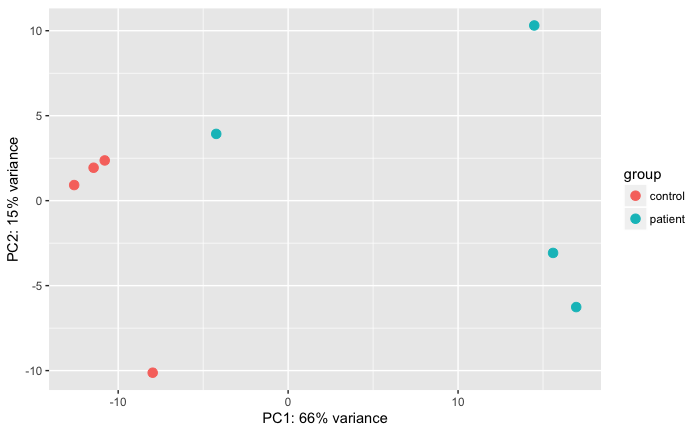

```r
#png("./pca.png")
DESeq2::plotPCA(rld, intgroup = c("group"),ntop = 100)
```

```r
#dev.off()
```

Differential expression analysis based on the Negative Binomial

```r
dds <- DESeq(dds)
res <- results(dds,alpha = 0.05)
res
```

```
log2 fold change (MAP): group patient vs control
Wald test p-value: group patient vs control
DataFrame with 29504 rows and 6 columns
                  baseMean log2FoldChange     lfcSE        stat      pvalue       padj
                 <numeric>      <numeric> <numeric>   <numeric>   <numeric>  <numeric>
ENSG00000000003  44.204924     -0.1344798 0.2489749  -0.5401339 0.589104663 0.87418630
ENSG00000000005   6.936064      1.3958662 0.4476498   3.1182105 0.001819528 0.03411748
ENSG00000000419 129.738179     -0.1333400 0.1798527  -0.7413845 0.458460353 0.80929434
ENSG00000000457 135.025670     -0.3955211 0.1904697  -2.0765561 0.037842551 0.25114888
ENSG00000000460  38.929227     -0.2992076 0.2698420  -1.1088250 0.267505693 0.65968395
...                    ...            ...       ...         ...         ...        ...
ENSG00000284523  5.3303125     0.04205183 0.4444117  0.09462359   0.9246138  0.9802391
ENSG00000284526  9.4357206    -0.67122080 0.4115512 -1.63095333   0.1029002  0.4263963
ENSG00000284543  0.6543641     0.39763521 0.3010185  1.32096596   0.1865127         NA
ENSG00000284584  0.5425716    -0.24930200 0.2527869 -0.98621395   0.3240281         NA
ENSG00000284594  0.6565386     0.27721225 0.3287618  0.84320084   0.3991161         NA
```

```r
summary(res)
```

```
out of 29504 with nonzero total read count
adjusted p-value < 0.05
LFC > 0 (up)     : 681, 2.3%
LFC < 0 (down)   : 494, 1.7%
outliers [1]     : 118, 0.4%
low counts [2]   : 10279, 35%
(mean count < 3)
[1] see 'cooksCutoff' argument of ?results
[2] see 'independentFiltering' argument of ?results
```

```r
table(res$padj < 0.05)
```

```
FALSE  TRUE
17932  1175
```

STAR data

```r
dds_star <- DESeq(dds_star)
res_star <- results(dds_star)
res_star
```

```
log2 fold change (MAP): group patient vs control
Wald test p-value: group patient vs control
DataFrame with 30014 rows and 6 columns
                  baseMean log2FoldChange     lfcSE       stat      pvalue       padj
                 <numeric>      <numeric> <numeric>  <numeric>   <numeric>  <numeric>
ENSG00000000003  40.838042    -0.09470382 0.2636921 -0.3591455 0.719486253 0.91812912
ENSG00000000005   6.502421     1.36732070 0.4484447  3.0490283 0.002295829 0.03991357
ENSG00000000419 127.712898    -0.11178560 0.1780392 -0.6278709 0.530088537 0.84358636
ENSG00000000457 130.571577    -0.37231354 0.1936296 -1.9228133 0.054503498 0.30634669
ENSG00000000460  37.915517    -0.28461168 0.2616378 -1.0878080 0.276679895 0.66696121
...                    ...            ...       ...        ...         ...        ...
ENSG00000284523  4.8252912      0.2087272 0.4476284  0.4662956   0.6410039  0.8933316
ENSG00000284526  9.6986083     -0.5555884 0.4074237 -1.3636625   0.1726738  0.5448949
ENSG00000284543  0.6548618      0.4034928 0.3034878  1.3295191   0.1836768         NA
ENSG00000284584  0.5445129     -0.2538985 0.2549606 -0.9958343   0.3193306         NA
ENSG00000284594  0.5344268      0.1685988 0.2873833  0.5866688   0.5574262         NA
```

```r
summary(res_star)
```

```
out of 30014 with nonzero total read count
adjusted p-value < 0.1
LFC > 0 (up)     : 932, 3.1%
LFC < 0 (down)   : 720, 2.4%
outliers [1]     : 108, 0.36%
low counts [2]   : 11043, 37%
(mean count < 3)
[1] see 'cooksCutoff' argument of ?results
[2] see 'independentFiltering' argument of ?results
```

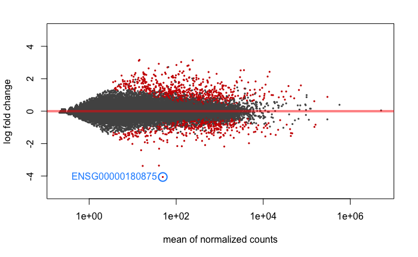

```r
#png("./MA.png")
DESeq2::plotMA(res, ylim = c(-5, 5))
topGene <- rownames(res)[which.min(res$padj)]
with(res[topGene, ], {
  points(baseMean, log2FoldChange, col="dodgerblue", cex=2, lwd=2)
  text(baseMean, log2FoldChange, topGene, pos=2, col="dodgerblue")
})
```

Count plots

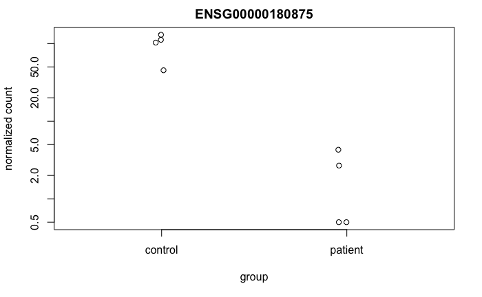

```r
topGene <- rownames(res)[which.min(res$padj)]
plotCounts(dds, gene = topGene, intgroup=c("group"))
```

Gene clustering

```r
library("genefilter")
topVarGenes <- head(order(rowVars(assay(rld)), decreasing = TRUE), 25)
```

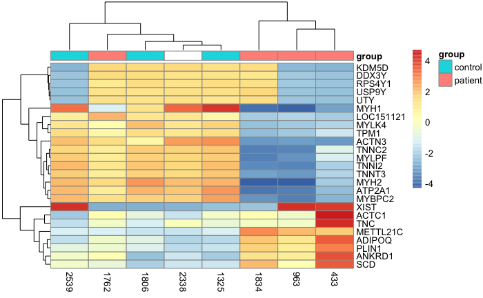

```r
mat  <- assay(rld)[ topVarGenes, ]
mat  <- mat - rowMeans(mat)
anno <- as.data.frame(colData(rld)[,c("group")])
row.names(anno) <- c(2238,1325,2539,1806,963,1762,1834,433)
colnames(anno) <- c("group")
pheatmap(mat, annotation_col = anno, labels_row = res[row.names(mat),"symbol"])
```

```r
#pheatmap(mat, annotation_col = anno, show_rownames=FALSE)#, filename = "hm200.png")
#pheatmap(mat,kmeans_k = 5)
```

### Annotation

```r
library("AnnotationDbi")
library("org.Hs.eg.db")
res$symbol = mapIds(org.Hs.eg.db,
                     keys=row.names(res),
                     column="SYMBOL",
                     keytype="ENSEMBL",
                     multiVals="first")
res$entrez = mapIds(org.Hs.eg.db,
                     keys=row.names(res),
                     column="ENTREZID",
                     keytype="ENSEMBL",
                     multiVals="first")
res$name =   mapIds(org.Hs.eg.db,
                     keys=row.names(res),
                     column="GENENAME",
                     keytype="ENSEMBL",
                     multiVals="first")
```

```r
head(res[order(res$padj),], 15)
```

```
log2 fold change (MAP): group patient vs control
Wald test p-value: group patient vs control
DataFrame with 15 rows and 9 columns
                  baseMean log2FoldChange     lfcSE       stat       pvalue         padj      symbol      entrez
                 <numeric>      <numeric> <numeric>  <numeric>    <numeric>    <numeric> <character> <character>
ENSG00000180875    49.1947      -4.058296 0.3923829 -10.342693 4.516622e-25 8.629910e-21       GREM2       64388
ENSG00000090020   243.9627       1.905881 0.1906061   9.999055 1.538584e-23 1.469887e-19      SLC9A1        6548
ENSG00000146592   412.9027       1.800822 0.1886213   9.547289 1.331342e-21 8.479318e-18       CREB5        9586
ENSG00000151948   192.3504       2.822237 0.3074623   9.179132 4.345790e-20 2.075875e-16      GLT1D1      144423
ENSG00000111245 73296.3176       1.586698 0.1810567   8.763543 1.892075e-18 7.230375e-15        MYL2        4633
...                    ...            ...       ...        ...          ...          ...         ...         ...
ENSG00000165887  3028.4873       2.515202 0.3158737   7.962681 1.683504e-15 2.924247e-12      ANKRD2       26287
ENSG00000168334 13985.7232       2.427420 0.3059985   7.932783 2.142888e-15 3.412013e-12       XIRP1      165904
ENSG00000006327   204.3094       2.557195 0.3270696   7.818505 5.345424e-15 7.187541e-12   TNFRSF12A       51330
ENSG00000140403  2929.4778       2.098393 0.2685784   7.812962 5.585965e-15 7.187541e-12      DNAJA4       55466
ENSG00000197580   288.7517       1.407332 0.1801572   7.811691 5.642598e-15 7.187541e-12        BCO2       83875
                                                            name
                                                     <character>
ENSG00000180875             gremlin 2, DAN family BMP antagonist
ENSG00000090020                solute carrier family 9 member A1
ENSG00000146592        cAMP responsive element binding protein 5
ENSG00000151948        glycosyltransferase 1 domain containing 1
ENSG00000111245                             myosin light chain 2
...                                                          ...
ENSG00000165887                          ankyrin repeat domain 2
ENSG00000168334            xin actin binding repeat containing 1
ENSG00000006327              TNF receptor superfamily member 12A
ENSG00000140403 DnaJ heat shock protein family (Hsp40) member A4
ENSG00000197580                        beta-carotene oxygenase 2
```

Top 10 gene sorted by log2FoldChange

```r
head(res[order(res$log2FoldChange),], 10)
```

```
log2 fold change (MAP): group patient vs control
Wald test p-value: group patient vs control
DataFrame with 10 rows and 9 columns
                   baseMean log2FoldChange     lfcSE       stat       pvalue         padj      symbol      entrez
                  <numeric>      <numeric> <numeric>  <numeric>    <numeric>    <numeric> <character> <character>
ENSG00000180875   49.194704      -4.058296 0.3923829 -10.342693 4.516622e-25 8.629910e-21       GREM2       64388
ENSG00000264424   17.000201      -3.376336 0.4375369  -7.716688 1.193914e-14 1.341889e-11        MYH4        4622
ENSG00000205279   40.144362      -3.355370 0.4102228  -8.179385 2.852959e-16 5.451149e-13       CTXN3      613212
ENSG00000148680   15.647423      -2.407468 0.4054100  -5.938354 2.878980e-09 7.433603e-07        HTR7        3363
ENSG00000237372   40.499236      -2.313224 0.4401420  -5.255631 1.475182e-07 2.072522e-05     UNQ6494   100129066
ENSG00000145358 1271.450420      -2.179589 0.3052005  -7.141498 9.231949e-13 5.926393e-10      DDIT4L      115265
ENSG00000162998  134.763133      -2.161738 0.3788469  -5.706099 1.155948e-08 2.427109e-06        FRZB        2487
ENSG00000250878  105.963877      -2.152709 0.3817919  -5.638436 1.716016e-08 3.345706e-06   METTL21EP      121952
ENSG00000178053  462.232433      -2.090404 0.2845753  -7.345697 2.046889e-13 1.700431e-10        MLF1        4291
ENSG00000265728    9.859736      -2.018372 0.4219757  -4.783146 1.725726e-06 1.592920e-04          NA          NA
                                                  name
                                           <character>
ENSG00000180875   gremlin 2, DAN family BMP antagonist
ENSG00000264424                   myosin heavy chain 4
ENSG00000205279                             cortexin 3
ENSG00000148680         5-hydroxytryptamine receptor 7
ENSG00000237372           uncharacterized LOC100129066
ENSG00000145358 DNA damage inducible transcript 4 like
ENSG00000162998               frizzled-related protein
ENSG00000250878 methyltransferase like 21E, pseudogene
ENSG00000178053              myeloid leukemia factor 1
ENSG00000265728                                     NA
```

```r
gene_ranked <- res[order(res$log2FoldChange ),]
gene_list <- gene_ranked[c("symbol","log2FoldChange")]
gene_list <- gene_list[complete.cases(gene_list),]
write.table(gene_list,file = "ranked_list1.rnk",sep ="\t" ,quote = FALSE,row.names = FALSE,col.names = FALSE)
```

```r
gene_ranked <- res[order(res$padj),]
gene_list <- gene_ranked[c("symbol","name","padj")]
gene_list <- gene_list[complete.cases(gene_list),]
#write.table(subset(gene_list,padj<0.05),file = "ranked_list.txt",sep ="\t" ,quote = FALSE,row.names = FALSE)
write.csv(subset(gene_list,padj<0.05),file ="ranked_list.csv",row.names = FALSE )
```

### Pathway analysis by gage

http://www.gettinggeneticsdone.com/2015/12/tutorial-rna-seq-differential.html http://bioconductor.org/packages/release/bioc/html/gage.html

```r
library(pathview)
library(gage)
library(gageData)
data(kegg.sets.hs)
data(sigmet.idx.hs)
#kegg.sets.hs = kegg.sets.hs[sigmet.idx.hs]
```

The gage() function requires a named vector of fold changes, where the names of the values are the Entrez gene IDs.

```r
foldchanges = res$log2FoldChange
names(foldchanges) = res$entrez
head(foldchanges)
```

```
      7105      64102       8813      57147      55732       2268
-0.1344798  1.3958662 -0.1333400 -0.3955211 -0.2992076 -0.1210142
```

```r
# Get the results
keggres = gage(foldchanges, gsets=kegg.sets.hs, same.dir=TRUE)
# Look at both up (greater), down (less), and statatistics.
lapply(keggres, head)
```

```
$greater
                                            p.geomean stat.mean       p.val     q.val set.size        exp1
hsa04350 TGF-beta signaling pathway       0.001549568  3.010098 0.001549568 0.2385038       82 0.001549568
hsa00561 Glycerolipid metabolism          0.002703387  2.862024 0.002703387 0.2385038       44 0.002703387
hsa04512 ECM-receptor interaction         0.003439959  2.740561 0.003439959 0.2385038       84 0.003439959
hsa05020 Prion diseases                   0.005163048  2.652901 0.005163048 0.2612716       31 0.005163048
hsa05414 Dilated cardiomyopathy           0.006280568  2.525642 0.006280568 0.2612716       85 0.006280568
hsa04810 Regulation of actin cytoskeleton 0.009096300  2.372375 0.009096300 0.2695876      198 0.009096300

$less
                                                      p.geomean stat.mean        p.val        q.val set.size         exp1
hsa00190 Oxidative phosphorylation                 6.861940e-09 -5.882760 6.861940e-09 1.427284e-06      125 6.861940e-09
hsa05012 Parkinson's disease                       3.032722e-08 -5.590831 3.032722e-08 3.154031e-06      124 3.032722e-08
hsa05010 Alzheimer's disease                       1.090052e-06 -4.824716 1.090052e-06 7.557692e-05      160 1.090052e-06
hsa05016 Huntington's disease                      1.282628e-03 -3.037817 1.282628e-03 6.669665e-02      174 1.282628e-03
hsa04650 Natural killer cell mediated cytotoxicity 9.692950e-03 -2.355908 9.692950e-03 4.032267e-01      108 9.692950e-03
hsa03010 Ribosome                                  2.368673e-02 -2.002776 2.368673e-02 8.211401e-01       87 2.368673e-02

$stats
                                          stat.mean     exp1
hsa04350 TGF-beta signaling pathway        3.010098 3.010098
hsa00561 Glycerolipid metabolism           2.862024 2.862024
hsa04512 ECM-receptor interaction          2.740561 2.740561
hsa05020 Prion diseases                    2.652901 2.652901
hsa05414 Dilated cardiomyopathy            2.525642 2.525642
hsa04810 Regulation of actin cytoskeleton  2.372375 2.372375
```

```r
sigGeneSet(keggres,cutoff = 0.05)
```

```
[1] "No heatmap produced for up-regulated gene sets, only 1 or none signficant."
[1] "gs.data needs to be a matrix-like object!"
[1] "gs.data needs to be a matrix-like object!"
[1] "there are 0 signficantly up-regulated gene sets"
[1] "there are 3 signficantly down-regulated gene sets"
$greater
     p.geomean stat.mean p.val q.val set.size exp1

$less
                                      p.geomean stat.mean        p.val        q.val set.size         exp1
hsa00190 Oxidative phosphorylation 6.861940e-09 -5.882760 6.861940e-09 1.427284e-06      125 6.861940e-09
hsa05012 Parkinson's disease       3.032722e-08 -5.590831 3.032722e-08 3.154031e-06      124 3.032722e-08
hsa05010 Alzheimer's disease       1.090052e-06 -4.824716 1.090052e-06 7.557692e-05      160 1.090052e-06

$stats
                                   stat.mean      exp1
hsa00190 Oxidative phosphorylation -5.882760 -5.882760
hsa05012 Parkinson's disease       -5.590831 -5.590831
hsa05010 Alzheimer's disease       -4.824716 -4.824716
```

process the results to pull out the top 5 upregulated pathways, then further process that just to get the IDs. We’ll use these KEGG pathway IDs downstream for plotting.

```r
# Get the upregulated pathways
keggrespathways = data.frame(id=rownames(keggres$greater), keggres$greater)
keggrespathways <- head(keggrespathways$id,5)
keggrespathways
```

[output not shown]

```r
# Get the IDs.
keggresids = substr(keggrespathways, start=1, stop=8)
keggresids
```

```
[1] "hsa04350" "hsa00561" "hsa04512" "hsa04810" "hsa04974"
```

Finally, the pathview() function in the pathview package makes the plots. Let’s write a function so we can loop through and draw plots for the top 5 pathways we created above.

```r
# Define plotting function for applying later
plot_pathway = function(pid) pathview(gene.data=foldchanges, pathway.id=pid, species="hsa", new.signature=FALSE)

# plot multiple pathways (plots saved to disk and returns a throwaway list object)
tmp = sapply(keggresids, function(pid) pathview(gene.data=foldchanges, pathway.id=pid, species="hsa"))
```

downregulated pathways

```r
keggrespathways_d = data.frame(id=rownames(keggres$less), keggres$less)
keggrespathways_d <- head(keggrespathways_d$id,5)
keggrespathways_d
```

[output not shown]

```r
keggresids_d = substr(keggrespathways_d, start=1, stop=8)
keggresids_d
```

```
[1] "hsa00190" "hsa04650" "hsa03010" "hsa00020" "hsa03030"
```

```r
plot_pathway = function(pid) pathview(gene.data=foldchanges, pathway.id=pid, species="hsa", new.signature=FALSE)
tmp = sapply(keggresids_d, function(pid) pathview(gene.data=foldchanges, pathway.id=pid, species="hsa"))
```

### edgeR

https://bioconductor.org/packages/release/bioc/vignettes/edgeR/inst/doc/edgeRUsersGuide.pdf

```r
library(edgeR)
files <- dir("./read_counts/HTSeq/",pattern="*\\.txt$")
RG <- readDGE(files, path="./read_counts/HTSeq/",header=FALSE, labels = c("1325","1762","1806","1834","2338","2539","433","963"))
```

```
Meta tags detected: __no_feature, __ambiguous, __too_low_aQual, __not_aligned, __alignment_not_unique
```

```r
group <- c("control","patient","control","patient","control","control","patient","patient")
edgeDF <- DGEList(counts=RG, group=group, genes = rownames(RG))
dim(edgeDF)
```

```
[1] 58238     8
```

Filter out low expressed genes

```r
#keep <- rowSums(cpm(edgeDF)>0.5) >= 2
keep <- rowSums(edgeDF$counts) > 1
DGE_list <- edgeDF[keep, , keep.lib.sizes=FALSE]
dim(DGE_list)
```

```
[1] 29509     8
```

Annotation

```r
DGE_list$genes$Symbol <- mapIds(org.Hs.eg.db, rownames(DGE_list),keytype="ENSEMBL", column="SYMBOL")
DGE_list$genes$Name <- mapIds(org.Hs.eg.db, rownames(DGE_list),keytype="ENSEMBL", column="GENENAME")
```

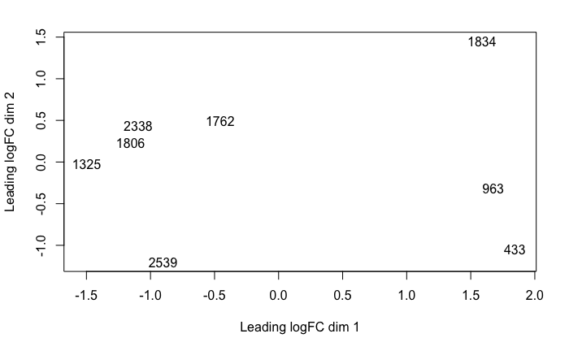

```r
plotMDS(DGE_list)
```

Genewise Negative Binomial Generalized Linear Models

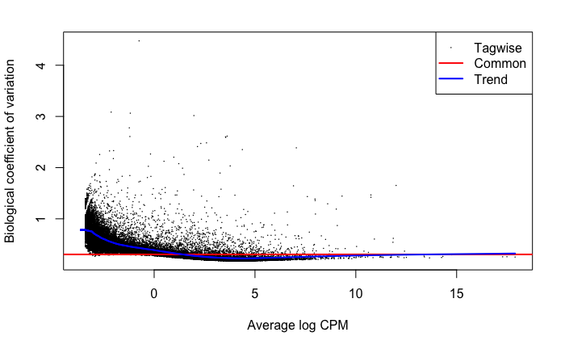

```r
library(statmod)
design <- model.matrix(~0+group, data=DGE_list$samples)
colnames(design) <- levels(DGE_list$samples$group)
y <- estimateDisp(DGE_list, design, robust=TRUE)
plotBCV(y)
```

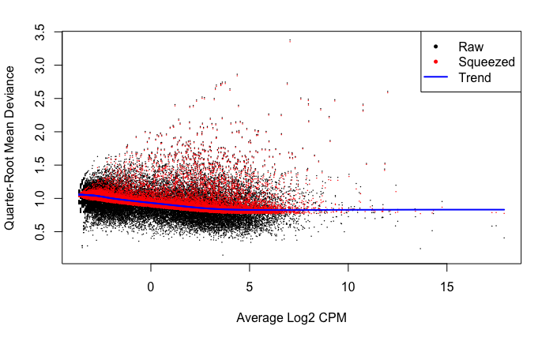

```r
fit <- glmQLFit(y, design, robust=TRUE)
plotQLDisp(fit)
```

Classic approach

pairwise comparisons between the groups

```r
et <- exactTest(y)
topTags(et)
```

```
Comparison of groups:  patient-control
                genes       Symbol                                      Name     logFC     logCPM       PValue          FDR
14947 ENSG00000180875        GREM2      gremlin 2, DAN family BMP antagonist -5.950277  0.9312043 2.536257e-23 7.484241e-19
9479  ENSG00000151948       GLT1D1 glycosyltransferase 1 domain containing 1  3.183924  2.7868089 1.118572e-16 1.650397e-12
48135 ENSG00000264424         MYH4                      myosin heavy chain 4 -8.154428 -0.4946438 6.440214e-16 6.334809e-12
1862  ENSG00000090020       SLC9A1         solute carrier family 9 member A1  1.930816  3.1439842 1.231454e-15 9.084744e-12
20169 ENSG00000205279        CTXN3                                cortexin 3 -5.063696  0.6161547 1.985339e-15 1.171707e-11
8866  ENSG00000146592        CREB5 cAMP responsive element binding protein 5  1.823002  3.9026673 1.350081e-14 6.639925e-11
14420 ENSG00000178053         MLF1                 myeloid leukemia factor 1 -2.427488  4.0894726 1.790700e-14 7.548825e-11
39070 ENSG00000250183         <NA>                                      <NA>  6.243995 -0.7876314 1.452378e-13 5.357278e-10
39218 ENSG00000250392 LOC100996694              uncharacterized LOC100996694  6.173890 -0.8569969 1.991171e-13 6.528608e-10
11297 ENSG00000164237         CMBL      carboxymethylenebutenolidase homolog -1.690011  5.5045758 4.365202e-13 1.288127e-09
```

```r
o <- order(et$table$PValue)
cpm(y)[o[1:10],]
```

```
                 Samples
Tags                   1325       1762       1806       1834        2338        2539         433        963
  ENSG00000180875  3.702288  0.1287788  1.6205624  0.0000000  4.46068436  4.66952032  0.00000000  0.0768932
  ENSG00000151948  1.414357  6.6643029  0.7275995 15.0535715  1.77065333  1.49969996  9.70489727 17.8776699
  ENSG00000264424  1.663950  0.0000000  0.9591084  0.0000000  1.94090846  0.54534544  0.00000000  0.0000000
  ENSG00000090020  3.910282 11.0749769  3.2411249 15.5379686  4.66499052  2.76081129 14.96332767 14.0330097
  ENSG00000205279  5.158244  0.1609735  3.1749795  0.0000000  1.39609205  1.70420450  0.07732986  0.0768932
  ENSG00000146592  4.284670 24.6933350  6.6806860 20.7918141  8.37655231  6.85090208 26.91079084 20.4920388
  ENSG00000178053 34.443756  9.1432948 27.1857617  3.5025637 25.57232028 27.19910378  3.55717350  4.9980583
  ENSG00000250183  0.000000  1.6741244  0.0000000  0.6334424  0.03405103  0.00000000  0.69596873  0.9996117
  ENSG00000250392  0.000000  0.8370622  0.0000000  1.4904526  0.00000000  0.03408409  0.50264408  0.9996117
  ENSG00000164237 66.391588 30.3596022 67.6336772 20.4937236 69.12358210 73.68980247 15.77529118 19.1079612
```

```r
FDR <- p.adjust(et$table$PValue, method="BH")
sum(FDR<0.05)
```

```
[1] 817
```

```r
top_e <- topTags(et,sum(FDR<0.05))
deseq_rank<- res[order(res$padj),]
deseq_list <-subset(deseq_rank,padj<0.05)
lista <- top_e$table$genes
listb <- row.names(deseq_list)
interlist <- lista[lista%in%listb]
```

```r
write.csv(topTags(et,40),file ="et30.csv",row.names = FALSE )
```

### Gene Ontology with topGO

```r
library(topGO)
#library(biomaRt)
all_genes <- unlist(split(et$table$PValue, row.names(et$table)))
GOdata <- new("topGOdata", ontology = "BP", allGenes = all_genes, geneSel = function(p) p < 1e-2, description = "Test", annot = annFUN.org, mapping="org.Hs.eg.db", ID="Ensembl")
```

```
Building most specific GOs .....
    ( 10739 GO terms found. )

Build GO DAG topology ..........
    ( 14583 GO terms and 34547 relations. )

Annotating nodes ...............
    ( 14174 genes annotated to the GO terms. )
```

enrichment tests

```r
resultFisher <- runTest(GOdata, algorithm = "classic", statistic = "fisher")
```

```
             -- Classic Algorithm --

         the algorithm is scoring 7178 nontrivial nodes
         parameters:
             test statistic: fisher
```

```r
resultKS <- runTest(GOdata, algorithm = "classic", statistic = "ks")
```

```
             -- Classic Algorithm --

         the algorithm is scoring 14583 nontrivial nodes
         parameters:
             test statistic: ks
             score order: increasing
```

```r
GenTable(GOdata, classicFisher = resultFisher,KS = resultKS,orderBy = "classicFisher", topNodes = 20)
```

|  | GO.ID | Term | Annotated | Significant | Expected | Rank in KS | classicFisher | KS |
| --- | --- | --- | --- | --- | --- | --- | --- | --- |
| 1 | GO:0003012 | muscle system process | 365 | 76 | 28.02 | 14 | 5.0e-16 | 1.7e-10 |
| 2 | GO:0006936 | muscle contraction | 295 | 66 | 22.64 | 10 | 1.1e-15 | 6.1e-11 |
| 3 | GO:0044710 | single-organism metabolic process | 3614 | 375 | 277.41 | 2 | 4.4e-12 | 3.1e-13 |
| 4 | GO:0060537 | muscle tissue development | 324 | 62 | 24.87 | 28 | 1.3e-11 | 6.0e-09 |
| 5 | GO:0061061 | muscle structure development | 539 | 86 | 41.37 | 20 | 4.2e-11 | 1.3e-09 |
| 6 | GO:0003008 | system process | 1332 | 167 | 102.24 | 21 | 4.4e-11 | 1.9e-09 |
| 7 | GO:0006941 | striated muscle contraction | 140 | 36 | 10.75 | 30 | 6.0e-11 | 7.4e-09 |
| 8 | GO:0032787 | monocarboxylic acid metabolic process | 463 | 77 | 35.54 | 106 | 6.1e-11 | 5.1e-06 |
| 9 | GO:0051146 | striated muscle cell differentiation | 214 | 46 | 16.43 | 65 | 1.1e-10 | 5.2e-07 |
| 10 | GO:0014706 | striated muscle tissue development | 310 | 58 | 23.80 | 37 | 1.5e-10 | 4.4e-08 |

[output cut: 10 more lines]

Box color represents the relative significance, ranging from dark red (most significant) to light yellow (least significant)

```r
library(Rgraphviz)
printGraph(GOdata, resultFisher, firstSigNodes = 10, fn.prefix = "tGO", useInfo = "all", pdfSW = TRUE)
```

```
tGO_classic_10_all  --- no of nodes:  29
```

```
$dag
A graphNEL graph with directed edges
Number of Nodes = 29
Number of Edges = 38

$complete.dag
[1] "A graph with 29 nodes."
```

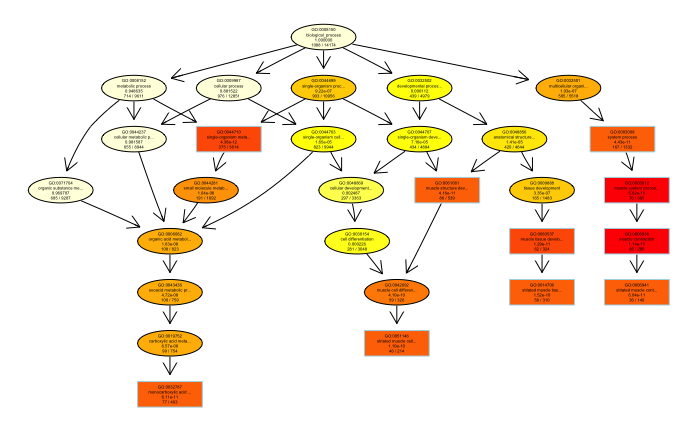

```r
showSigOfNodes(GOdata, score(resultFisher), firstSigNodes = 10, useInfo = 'all')
```

# Gene Set Enrichment Analysis

## SeqGSEA

https://www.bioconductor.org/packages/devel/bioc/vignettes/SeqGSEA/inst/doc/SeqGSEA.pdf

Load files

```r
library(SeqGSEA)
dat.dir = system.file("extdata", package="SeqGSEA", mustWork=TRUE)
case.files <- dir("./read_counts/case/", pattern=NULL, full.names = TRUE)
control.files <- dir("./read_counts/ctrl/", pattern=NULL, full.names = TRUE)
geneset.file <- system.file("extdata", "gs_symb.txt", package="SeqGSEA", mustWork=TRUE)
```

```r
# output file prefix
output.prefix <- "SeqGSEA.test"
# setup parallel backend
library(doParallel)
cl <- makeCluster(2) # specify 2 cores to be used in computing
registerDoParallel(cl) # parallel backend registration
# setup permutation times
perm.times <- 1000
```

load exon read count data, remove genes with low expression

```r
RCS <- loadExonCountData(case.files, control.files)
RCS <- exonTestability(RCS, cutoff=5)
```

```r
geneTestable <- geneTestability(RCS)
RCS <- subsetByGenes(RCS, unique(geneID(RCS))[geneTestable])
```

get gene IDs, which will be used in initialization of gene set

```r
geneIDs <- unique(geneID(RCS))
# calculate DS NB statistics
RCS <- estiExonNBstat(RCS)
```

```r
# get gene read counts
geneCounts <- getGeneCount(RCS)
# calculate DE NB statistics
label <- label(RCS)
DEG <-runDESeq(geneCounts, label)
DEGres <- DENBStat4GSEA(DEG)
# calculate DE NB statistics on the permutation data sets
permuteMat <- genpermuteMat(RCS, times=perm.times)
DEpermNBstat <- DENBStatPermut4GSEA(DEG, permuteMat) # permutation
```

```r
# DE score normalization
DEscore.normFac <- normFactor(DEpermNBstat)
DEscore <- scoreNormalization(DEGres$NBstat, DEscore.normFac)
DEscore.perm <- scoreNormalization(DEpermNBstat, DEscore.normFac)
# score integration - DSscore can be null
gene.score <- geneScore(DEscore, DEweight=1)
gene.score.perm <- genePermuteScore(DEscore.perm, DEweight=1) # visilization of scores

#plotGeneScore(DEscore, DEscore.perm, pdf=paste(output.prefix,".DEScore.pdf",sep=""), main="Expression")
#plotGeneScore(gene.score, gene.score.perm,
#pdf=paste(output.prefix,".GeneScore.pdf",sep=""))
```

```r
plotGeneScore(DEscore, DEscore.perm, main="Expression")
```

[output not shown]

```r
plotGeneScore(gene.score, gene.score.perm)
```

[output not shown]

```r
# load gene set data
geneIDs <- rownames(geneCounts)
gene.set <- loadGenesets(geneset.file, geneIDs, geneID.type="ensembl",genesetsize.min = 5, genesetsize.max = 1000)
# enrichment analysis
gene.set <- GSEnrichAnalyze(gene.set, gene.score, gene.score.perm, weighted.type=1)
# format enrichment analysis results
GSEAres <- GSEAresultTable(gene.set, TRUE)

# output results
write.table(GSEAres, paste(output.prefix,".GSEA.result.txt",sep=""),quote=FALSE, sep="\t", row.names=FALSE)

#plotES(gene.set, pdf=paste(output.prefix,".GSEA.ES.pdf",sep=""))
#plotSig(gene.set, pdf=paste(output.prefix,".GSEA.FDR.pdf",sep=""))
```

```r
plotES(gene.set)
```

[output not shown]

```r
plotSig(gene.set)
```

[output not shown]